# RNA-seq analysis in R

Pre-processsing RNA-seq data

Mark Dunning

Last modified: 08 Jul 2018

**Original Authors: Belinda Phipson, Anna Trigos, Matt Ritchie, Maria Doyle, Harriet Dashnow, Charity Law**, **Stephane Ballereau, Oscar Rueda, Ashley Sawle** Based on the course [RNAseq analysis in R](http://combine-australia.github.io/2016-05-11-RNAseq/) delivered on May 11/12th 2016 and modified by Cancer Research Uk Cambridge Centre for the [Functional Genomics Autumn School 2017](https://bioinformatics-core-shared-training.github.io/cruk-autumn-school-2017/)

## Resources and data files

This material has been created using the following resources:  
http://www.statsci.org/smyth/pubs/QLedgeRPreprint.pdf (Lun, Chen, and Smyth 2016)  
http://monashbioinformaticsplatform.github.io/RNAseq-DE-analysis-with-R/99-RNAseq_DE_analysis_with_R.html  
http://bioconductor.org/packages/devel/bioc/vignettes/DESeq2/inst/doc/DESeq2.html

Data files downloaded from:  
ftp://ftp.ncbi.nlm.nih.gov/geo/series/GSE60nnn/GSE60450/suppl/GSE60450_Lactation-GenewiseCounts.txt.gz http://bioinf.wehi.edu.au/software/MSigDB/mouse_c2_v5.rdata http://bioinf.wehi.edu.au/software/MSigDB/mouse_H_v5.rdata

Data files:  
sampleinfo.txt  
GSE60450_Lactation-GenewiseCounts.txt  
mouse_c2_v5.rdata  
mouse_H_v5.rdata

Data files available from: https://figshare.com/s/1d788fd384d33e913a2a You should download these files and place them in your `/data` directory.

Packages used: limma, edgeR, gplots, org.Mm.eg.db, RColorBrewer, Glimma

## Overview

- Reading in table of counts
- Filtering lowly expressed genes
- Quality control
- Normalisation for composition bias

## Introduction

Measuring gene expression on a genome-wide scale has become common practice over the last two decades or so, with microarrays predominantly used pre-2008. With the advent of next generation sequencing technology in 2008, an increasing number of scientists use this technology to measure and understand changes in gene expression in often complex systems. As sequencing costs have decreased, using RNA-Seq to simultaneously measure the expression of tens of thousands of genes for multiple samples has never been easier. The cost of these experiments has now moved from generating the data to storing and analysing it.

There are many steps involved in analysing an RNA-Seq experiment. Analysing an RNAseq experiment begins with sequencing reads. These are aligned to a reference genome, then the number of reads mapped to each gene can be counted. This results in a table of counts, which is what we perform statistical analyses on in R. While mapping and counting are important and necessary tasks, today we will be starting from the count data and getting stuck into analysis.

### Mouse mammary gland dataset

The data for this tutorial comes from a Nature Cell Biology paper, [*EGF-mediated induction of Mcl-1 at the switch to lactation is essential for alveolar cell survival*](http://www.ncbi.nlm.nih.gov/pubmed/25730472) (Fu et al. 2015). Both the raw data (sequence reads) and processed data (counts) can be downloaded from Gene Expression Omnibus database (GEO) under accession number GSE60450.

This study examines the expression profiles of basal stem-cell enriched cells (B) and committed luminal cells (L) in the mammary gland of virgin, pregnant and lactating mice. Six groups are present, with one for each combination of cell type and mouse status. Each group contains two biological replicates.

The sampleinfo file contains basic information about the samples that we will need for the analysis today.

```r
# Read the sample information into R
sampleinfo <- read.delim("data/SampleInfo.txt")
View(sampleinfo)
sampleinfo
```

| FileName | SampleName | CellType | Status |
| --- | --- | --- | --- |
| MCL1.DG_BC2CTUACXX_ACTTGA_L002_R1 | MCL1.DG | luminal | virgin |
| MCL1.DH_BC2CTUACXX_CAGATC_L002_R1 | MCL1.DH | basal | virgin |
| MCL1.DI_BC2CTUACXX_ACAGTG_L002_R1 | MCL1.DI | basal | pregnant |
| MCL1.DJ_BC2CTUACXX_CGATGT_L002_R1 | MCL1.DJ | basal | pregnant |
| MCL1.DK_BC2CTUACXX_TTAGGC_L002_R1 | MCL1.DK | basal | lactate |
| MCL1.DL_BC2CTUACXX_ATCACG_L002_R1 | MCL1.DL | basal | lactate |
| MCL1.LA_BC2CTUACXX_GATCAG_L001_R1 | MCL1.LA | basal | virgin |
| MCL1.LB_BC2CTUACXX_TGACCA_L001_R1 | MCL1.LB | luminal | virgin |
| MCL1.LC_BC2CTUACXX_GCCAAT_L001_R1 | MCL1.LC | luminal | pregnant |
| MCL1.LD_BC2CTUACXX_GGCTAC_L001_R1 | MCL1.LD | luminal | pregnant |

[output cut: 2 more lines]

### Reading in the count data

We will first use the counts file as a starting point for our analysis. This data has already been aligned to the mouse genome. The command line tool featureCounts (Liao, Smyth, and Shi 2014) was used to count reads mapped to mouse genes from Refseq annotation (see the [paper](http://www.ncbi.nlm.nih.gov/pubmed/25730472) for details).

Let’s take a look at the data. You can use the `head` command to see the first 6 lines. In RStudio the `View` command will open the dataframe in a new tab. The `dim` command will tell you how many rows and columns the data frame has.

```r
# Read the data into R
seqdata <- read.delim("data/GSE60450_Lactation-GenewiseCounts.txt", stringsAsFactors = FALSE)
head(seqdata)
```

|  | EntrezGeneID | Length | MCL1.DG_BC2CTUACXX_ACTTGA_L002_R1 | MCL1.DH_BC2CTUACXX_CAGATC_L002_R1 | MCL1.DI_BC2CTUACXX_ACAGTG_L002_R1 | MCL1.DJ_BC2CTUACXX_CGATGT_L002_R1 | MCL1.DK_BC2CTUACXX_TTAGGC_L002_R1 | MCL1.DL_BC2CTUACXX_ATCACG_L002_R1 | MCL1.LA_BC2CTUACXX_GATCAG_L001_R1 | MCL1.LB_BC2CTUACXX_TGACCA_L001_R1 | MCL1.LC_BC2CTUACXX_GCCAAT_L001_R1 | MCL1.LD_BC2CTUACXX_GGCTAC_L001_R1 | MCL1.LE_BC2CTUACXX_TAGCTT_L001_R1 | MCL1.LF_BC2CTUACXX_CTTGTA_L001_R1 |
| --- | --- | --- | --- | --- | --- | --- | --- | --- | --- | --- | --- | --- | --- | --- |
| 1 | 497097 | 3634 | 438 | 300 | 65 | 237 | 354 | 287 | 0 | 0 | 0 | 0 | 0 | 0 |
| 2 | 100503874 | 3259 | 1 | 0 | 1 | 1 | 0 | 4 | 0 | 0 | 0 | 0 | 0 | 0 |
| 3 | 100038431 | 1634 | 0 | 0 | 0 | 0 | 0 | 0 | 0 | 0 | 0 | 0 | 0 | 0 |
| 4 | 19888 | 9747 | 1 | 1 | 0 | 0 | 0 | 0 | 10 | 3 | 10 | 2 | 0 | 0 |
| 5 | 20671 | 3130 | 106 | 182 | 82 | 105 | 43 | 82 | 16 | 25 | 18 | 8 | 3 | 10 |
| 6 | 27395 | 4203 | 309 | 234 | 337 | 300 | 290 | 270 | 560 | 464 | 489 | 328 | 307 | 342 |

```r
View(seqdata)
dim(seqdata)
```

```
[1] 27179    14
```

The `seqdata` object contains information about genes (one gene per row), the first column has the Entrez gene id, the second has the gene length and the remaining columns contain information about the number of reads aligning to the gene in each experimental sample. There are two replicates for each cell type and timepoint (detailed sample info can be found in file “GSE60450_series_matrix.txt” from the [GEO website](http://www.ncbi.nlm.nih.gov/geo/query/acc.cgi?acc=GSE60450)).

### Format the data

We will be manipulating and reformatting the counts matrix into a suitable format for downstream analysis. The first two columns in the `seqdata` dataframe contain annotation information. We need to make a new matrix containing only the counts, but we can store the gene identifiers (the `EntrezGeneID` column) as rownames. We will add more annotation information about each gene later on in the workshop.

```r
head(seqdata)
```

|  | EntrezGeneID | Length | MCL1.DG_BC2CTUACXX_ACTTGA_L002_R1 | MCL1.DH_BC2CTUACXX_CAGATC_L002_R1 | MCL1.DI_BC2CTUACXX_ACAGTG_L002_R1 | MCL1.DJ_BC2CTUACXX_CGATGT_L002_R1 | MCL1.DK_BC2CTUACXX_TTAGGC_L002_R1 | MCL1.DL_BC2CTUACXX_ATCACG_L002_R1 | MCL1.LA_BC2CTUACXX_GATCAG_L001_R1 | MCL1.LB_BC2CTUACXX_TGACCA_L001_R1 | MCL1.LC_BC2CTUACXX_GCCAAT_L001_R1 | MCL1.LD_BC2CTUACXX_GGCTAC_L001_R1 | MCL1.LE_BC2CTUACXX_TAGCTT_L001_R1 | MCL1.LF_BC2CTUACXX_CTTGTA_L001_R1 |
| --- | --- | --- | --- | --- | --- | --- | --- | --- | --- | --- | --- | --- | --- | --- |
| 1 | 497097 | 3634 | 438 | 300 | 65 | 237 | 354 | 287 | 0 | 0 | 0 | 0 | 0 | 0 |
| 2 | 100503874 | 3259 | 1 | 0 | 1 | 1 | 0 | 4 | 0 | 0 | 0 | 0 | 0 | 0 |
| 3 | 100038431 | 1634 | 0 | 0 | 0 | 0 | 0 | 0 | 0 | 0 | 0 | 0 | 0 | 0 |
| 4 | 19888 | 9747 | 1 | 1 | 0 | 0 | 0 | 0 | 10 | 3 | 10 | 2 | 0 | 0 |
| 5 | 20671 | 3130 | 106 | 182 | 82 | 105 | 43 | 82 | 16 | 25 | 18 | 8 | 3 | 10 |
| 6 | 27395 | 4203 | 309 | 234 | 337 | 300 | 290 | 270 | 560 | 464 | 489 | 328 | 307 | 342 |

```r
rownames(seqdata)[1:10]
```

```
 [1] "1"  "2"  "3"  "4"  "5"  "6"  "7"  "8"  "9"  "10"
```

Let’s create a new data object, `countdata`, that contains only the counts for the 12 samples.

```r
# Remove first two columns from seqdata
countdata <- seqdata[,-(1:2)]
# Store EntrezGeneID as rownames
rownames(countdata) <- seqdata[,1]
View(countdata)
```

Now take a look at the column names

```r
colnames(countdata)
```

```
 [1] "MCL1.DG_BC2CTUACXX_ACTTGA_L002_R1" "MCL1.DH_BC2CTUACXX_CAGATC_L002_R1"
 [3] "MCL1.DI_BC2CTUACXX_ACAGTG_L002_R1" "MCL1.DJ_BC2CTUACXX_CGATGT_L002_R1"
 [5] "MCL1.DK_BC2CTUACXX_TTAGGC_L002_R1" "MCL1.DL_BC2CTUACXX_ATCACG_L002_R1"
 [7] "MCL1.LA_BC2CTUACXX_GATCAG_L001_R1" "MCL1.LB_BC2CTUACXX_TGACCA_L001_R1"
 [9] "MCL1.LC_BC2CTUACXX_GCCAAT_L001_R1" "MCL1.LD_BC2CTUACXX_GGCTAC_L001_R1"
[11] "MCL1.LE_BC2CTUACXX_TAGCTT_L001_R1" "MCL1.LF_BC2CTUACXX_CTTGTA_L001_R1"
```

These are the sample names which are pretty long so we’ll shorten these to contain only the relevant information about each sample. We will use the `substr` command to extract the first 7 characters and use these as the colnames.

```r
substr("ThisIsAString", start=1, stop=5)
```

```
[1] "ThisI"
```

```r
# using substr, you can extract the samplename:
colnames(countdata) <- substr(colnames(countdata), 1, 7)
View(countdata)
colnames(countdata)
```

```
 [1] "MCL1.DG" "MCL1.DH" "MCL1.DI" "MCL1.DJ" "MCL1.DK" "MCL1.DL" "MCL1.LA" "MCL1.LB" "MCL1.LC"
[10] "MCL1.LD" "MCL1.LE" "MCL1.LF"
```

Note that the column names are now the same as `SampleName` in the `sampleinfo` file. This is good because it means our sample information in `sampleinfo` is in the same order as the columns in `countdata`.

```r
colnames(countdata)==sampleinfo$SampleName
```

```
 [1] TRUE TRUE TRUE TRUE TRUE TRUE TRUE TRUE TRUE TRUE TRUE TRUE
```

```r
all(colnames(countdata)==sampleinfo$SampleName)
```

```
[1] TRUE
```

## Filtering to remove lowly expressed genes

Genes with very low counts across all libraries provide little evidence for differential expression and they interfere with some of the statistical approximations that are used later in the pipeline. They also add to the multiple testing burden when estimating false discovery rates, reducing power to detect differentially expressed genes. These genes should be filtered out prior to further analysis.

There are a few ways to filter out lowly expressed genes. When there are biological replicates in each group, in this case we have a sample size of 2 in each group, we favour filtering on a minimum counts per million threshold present in at least 2 samples. Two represents the smallest sample size for each group in our experiment. In this dataset, we choose to retain genes if they are expressed at a counts-per-million (CPM) above 0.5 in at least two samples.

```r
colSums(countdata)
```

```
 MCL1.DG  MCL1.DH  MCL1.DI  MCL1.DJ  MCL1.DK  MCL1.DL  MCL1.LA  MCL1.LB  MCL1.LC  MCL1.LD  MCL1.LE
23227641 21777891 24100765 22665371 21529331 20015386 20392113 21708152 22241607 21988240 24723827
 MCL1.LF
24657293
```

We’ll use the `cpm` function from the *edgeR* library (Robinson, McCarthy, and Smyth 2010) to generate the CPM values and then filter. Note that by converting to CPMs we are normalising for the different sequencing depths for each sample.

```r
library(edgeR)
# Obtain CPMs
myCPM <- cpm(countdata)
# Have a look at the output
head(myCPM)
```

```
              MCL1.DG     MCL1.DH     MCL1.DI     MCL1.DJ   MCL1.DK    MCL1.DL    MCL1.LA    MCL1.LB
497097    18.85684388 13.77543859  2.69700983 10.45648006 16.442685 14.3389690  0.0000000  0.0000000
100503874  0.04305215  0.00000000  0.04149246  0.04412017  0.000000  0.1998463  0.0000000  0.0000000
100038431  0.00000000  0.00000000  0.00000000  0.00000000  0.000000  0.0000000  0.0000000  0.0000000
19888      0.04305215  0.04591813  0.00000000  0.00000000  0.000000  0.0000000  0.4903857  0.1381969
20671      4.56352843  8.35709941  3.40238163  4.63261775  1.997275  4.0968483  0.7846171  1.1516411
27395     13.30311589 10.74484210 13.98295863 13.23605071 13.469996 13.4896224 27.4615975 21.3744588
             MCL1.LC     MCL1.LD    MCL1.LE    MCL1.LF
497097     0.0000000  0.00000000  0.0000000  0.0000000
100503874  0.0000000  0.00000000  0.0000000  0.0000000
100038431  0.0000000  0.00000000  0.0000000  0.0000000
19888      0.4496078  0.09095771  0.0000000  0.0000000
20671      0.8092940  0.36383085  0.1213404  0.4055595
27395     21.9858214 14.91706476 12.4171715 13.8701357
```

```r
col1sum <- sum(countdata[,1])/1000000
countdata[1,1]/col1sum
```

```
[1] 18.85684
```

```r
# Which values in myCPM are greater than 0.5?
thresh <- myCPM > 0.5
# This produces a logical matrix with TRUEs and FALSEs
head(thresh)
```

```
          MCL1.DG MCL1.DH MCL1.DI MCL1.DJ MCL1.DK MCL1.DL MCL1.LA MCL1.LB MCL1.LC MCL1.LD MCL1.LE
497097       TRUE    TRUE    TRUE    TRUE    TRUE    TRUE   FALSE   FALSE   FALSE   FALSE   FALSE
100503874   FALSE   FALSE   FALSE   FALSE   FALSE   FALSE   FALSE   FALSE   FALSE   FALSE   FALSE
100038431   FALSE   FALSE   FALSE   FALSE   FALSE   FALSE   FALSE   FALSE   FALSE   FALSE   FALSE
19888       FALSE   FALSE   FALSE   FALSE   FALSE   FALSE   FALSE   FALSE   FALSE   FALSE   FALSE
20671        TRUE    TRUE    TRUE    TRUE    TRUE    TRUE    TRUE    TRUE    TRUE   FALSE   FALSE
27395        TRUE    TRUE    TRUE    TRUE    TRUE    TRUE    TRUE    TRUE    TRUE    TRUE    TRUE
          MCL1.LF
497097      FALSE
100503874   FALSE
100038431   FALSE
19888       FALSE
20671       FALSE
27395        TRUE
```

```r
# Summary of how many TRUEs there are in each row
# There are 11433 genes that have TRUEs in all 12 samples.
rowSums(head(thresh))
```

```
   497097 100503874 100038431     19888     20671     27395
        6         0         0         0         9        12
```

```r
table(rowSums(thresh))
```

```
    0     1     2     3     4     5     6     7     8     9    10    11    12
10857   518   544   307   346   307   652   323   547   343   579   423 11433
```

```r
# we would like to keep genes that have at least 2 TRUES in each row of thresh
keep <- rowSums(thresh) >= 2
summary(keep)
```

```
   Mode   FALSE    TRUE
logical   11375   15804
```

```r
# Subset the rows of countdata to keep the more highly expressed genes
counts.keep <- countdata[keep,]
dim(countdata)
```

```
[1] 27179    12
```

```r
dim(counts.keep)
```

```
[1] 15804    12
```

A CPM of 0.5 is used as it corresponds to a count of 10-15 for the library sizes in this data set. If the count is any smaller, it is considered to be very low, indicating that the associated gene is not expressed in that sample. A requirement for expression in two or more libraries is used as each group contains two replicates. This ensures that a gene will be retained if it is only expressed in one group. Smaller CPM thresholds are usually appropriate for larger libraries. As a general rule, a good threshold can be chosen by identifying the CPM that corresponds to a count of 10, which in this case is about 0.5. You should filter with CPMs rather than filtering on the counts directly, as the latter does not account for differences in library sizes between samples.

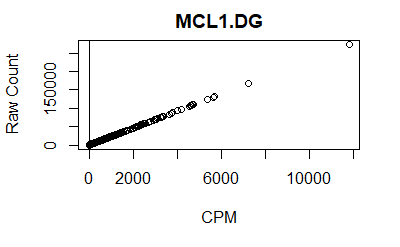

```r
# Let's have a look and see whether our threshold of 0.5 does indeed correspond to a count of about 10-15
# We will look at the first sample
plot(myCPM[,1], countdata[,1], xlab="CPM", ylab="Raw Count", main=colnames(myCPM)[1])
# Add a vertical line at 0.5 CPM
abline(v=0.5)
```

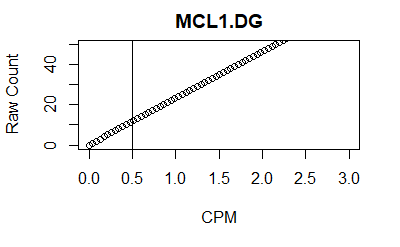

```r
# Let us limit the x and y-axis so we can actually look to see what is happening at the smaller counts
plot(myCPM[,1],countdata[,1], xlab="CPM", ylab="Raw Count", main=colnames(myCPM)[1],
     ylim=c(0,50), xlim=c(0,3))
# Add a vertical line at 0.5 CPM
abline(v=0.5)
```

## Challenge 1

> 1. Plot the counts-per-million versus counts for the second sample.
> 2. Add a vertical line at 0.5 and a horizontal line at 10.
> 3. Add the lines again, colouring them blue

> HINT: use the `col` parameter.

## Convert counts to DESeq2 object

Next we’ll create a `DESeqDataSet` object. This is an object used by *DESeq2* to store count data. It has a number of slots for storing various parameters about the data.

```r
### Create a DESeq2 object
library(DESeq2)
dds <- DESeqDataSetFromMatrix(counts.keep,
                              colData = sampleinfo,
                              design = ~CellType)
dds
```

```
class: DESeqDataSet
dim: 15804 12
metadata(1): version
assays(1): counts
rownames(15804): 497097 20671 ... 100861924 170942
rowData names(0):
colnames(12): MCL1.DG MCL1.DH ... MCL1.LE MCL1.LF
colData names(4): FileName SampleName CellType Status
```

## Quality control

### Library sizes and distribution plots

First, we can check how many reads we have for each sample in the `DESeqDataSet`.

```r
colSums(assay(dds))
```

```
 MCL1.DG  MCL1.DH  MCL1.DI  MCL1.DJ  MCL1.DK  MCL1.DL  MCL1.LA  MCL1.LB  MCL1.LC  MCL1.LD  MCL1.LE
23218026 21768136 24091588 22656713 21522033 20008326 20384562 21698793 22235847 21982745 24719697
 MCL1.LF
24652963
```

We can also plot the library sizes as a barplot to see whether there are any major discrepancies between the samples more easily.

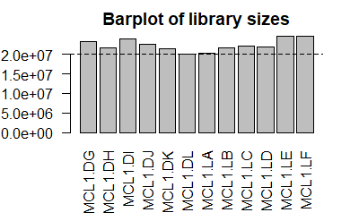

```r
# The names argument tells the barplot to use the sample names on the x-axis
# The las argument rotates the axis names
barplot(colSums(assay(dds)), names=colData(dds)$SampleName, las=2, main="Barplot of library sizes")
abline(h=20e6, lty=2)
```

```r
colSums(assay(dds))
```

```
 MCL1.DG  MCL1.DH  MCL1.DI  MCL1.DJ  MCL1.DK  MCL1.DL  MCL1.LA  MCL1.LB  MCL1.LC  MCL1.LD  MCL1.LE
23218026 21768136 24091588 22656713 21522033 20008326 20384562 21698793 22235847 21982745 24719697
 MCL1.LF
24652963
```

Count data is not normally distributed, so if we want to examine the distributions of the raw counts we need to log the counts. Next we’ll use box plots to check the distribution of the read counts on the log2 scale. We can use the `vst` function from `DESeq2`to apply a *variance-stablising transformation*. The effect is to remove the dependence of the variance on the mean, particularly the high variance of the logarithm of count data when the mean is low. The resulting counts have also been normalized with respect to library size or other normalization factors. For more details see the [DESeq2 vignette](http://bioconductor.org/packages/devel/bioc/vignettes/DESeq2/inst/doc/DESeq2.html#count-data-transformations)

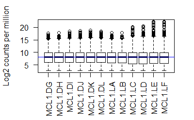

```r
# Get log2 counts
vsd <- vst(dds,blind=TRUE)
# Check distributions of samples using boxplots
boxplot(assay(vsd), xlab="", ylab="Log2 counts per million",las=2)
# Let's add a blue horizontal line that corresponds to the median logCPM
abline(h=median(assay(vsd)), col="blue", main="Boxplots of logCPMs (unnormalised)")
```

From the boxplots we see that overall the density distributions of raw log-intensities are not identical but still not very different. If a sample is really far above or below the blue horizontal line we may need to investigate that sample further.

## Discussion

> Do any samples appear to be different compared to the others?

### Heatmap of the sample-to-sample distances

Another use of the transformed data is sample clustering. Here, we apply the `dist` function to the transpose of the transformed count matrix to get sample-to-sample distances.

```r
sampleDists <- dist(t(assay(vsd)))
```

A heatmap of this distance matrix gives us an overview over similarities and dissimilarities between samples. We have to provide a hierarchical clustering hc to the heatmap function based on the sample distances, or else the heatmap function would calculate a clustering based on the distances between the rows/columns of the distance matrix.

```r
library(RColorBrewer)
library(pheatmap)
sampleDistMatrix <- as.matrix(sampleDists)
rownames(sampleDistMatrix) <- paste(vsd$CellType, vsd$Status, sep="-")
colnames(sampleDistMatrix) <- NULL
colors <- colorRampPalette( rev(brewer.pal(9, "Blues")) )(255)
pheatmap(sampleDistMatrix,
         clustering_distance_rows=sampleDists,
         clustering_distance_cols=sampleDists,
         col=colors)
```

[output not shown]

### Principal component (PCA) plot and Multi-Dimensional Scaling (MDS) of the samples

Related to the distance matrix is the [(Principal Components Analysis) PCA](http://setosa.io/ev/principal-component-analysis/) plot, which shows the samples in the 2D plane spanned by their first two principal components. A principle components analysis is an example of an unsupervised analysis, where we don’t need to specify the groups. If your experiment is well controlled and has worked well, what we hope to see is that the greatest sources of variation in the data are the treatments/groups we are interested in. It is also an incredibly useful tool for quality control and checking for outliers

`DESeq2` has a convenient `plotPCA` function for making the PCA plot, which makes use of the `ggplot2` graphics package.

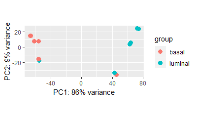

```r
plotPCA(vsd,intgroup="CellType")
```

## Challenge 2

> 1. Is the plot based on all genes in the dataset? How can we change how many genes are used for the PCA analysis?
> 2. Change the `intgroup` parameter so that both CellType and Status are used for grouping. HINT: check the documentation for the `plotPCA` function.
> 3. Is there something strange going on with the samples?
> 4. Identify the two samples that don’t appear to be in the right place.

### Note about batch effects

In our unsupervised analysis we see that the main source of variation is due to biological effects, and not technical variation such as when the libraries were sequenced. If we do observe high technical variation in our data, it is not a complete disaster provided that we have designed our experiment propery. In particular the [sva Bioconductor package](https://bioconductor.org/packages/release/bioc/vignettes/sva/inst/doc/sva.pdf) can correct for batch effects provided that representatives of the groups of interest appear in each batch. Alternatively, the batch or confounding factor may be incorporated into the differential expression analysis.

### Correcting the sample information

Hopefully we have spotted a potential sample swap in the dataset. Such errors are not uncommon when handling large numbers of samples and sometimes we need to go back to the lab books and verify that a swap has been made. *If there is no supporting evidence for a swap then it can be safer to exclude the samples*. In this case, we are going to use a correct sample sheet.

```r
# There is a sample info corrected file in your data directory
# Old sampleinfo
sampleinfo
```

| FileName | SampleName | CellType | Status |
| --- | --- | --- | --- |
| MCL1.DG_BC2CTUACXX_ACTTGA_L002_R1 | MCL1.DG | luminal | virgin |
| MCL1.DH_BC2CTUACXX_CAGATC_L002_R1 | MCL1.DH | basal | virgin |
| MCL1.DI_BC2CTUACXX_ACAGTG_L002_R1 | MCL1.DI | basal | pregnant |
| MCL1.DJ_BC2CTUACXX_CGATGT_L002_R1 | MCL1.DJ | basal | pregnant |
| MCL1.DK_BC2CTUACXX_TTAGGC_L002_R1 | MCL1.DK | basal | lactate |
| MCL1.DL_BC2CTUACXX_ATCACG_L002_R1 | MCL1.DL | basal | lactate |
| MCL1.LA_BC2CTUACXX_GATCAG_L001_R1 | MCL1.LA | basal | virgin |
| MCL1.LB_BC2CTUACXX_TGACCA_L001_R1 | MCL1.LB | luminal | virgin |
| MCL1.LC_BC2CTUACXX_GCCAAT_L001_R1 | MCL1.LC | luminal | pregnant |
| MCL1.LD_BC2CTUACXX_GGCTAC_L001_R1 | MCL1.LD | luminal | pregnant |

[output cut: 2 more lines]

```r
# I'm going to write over the sampleinfo object with the corrected sample info
sampleinfo <- read.delim("data/SampleInfo_Corrected.txt")
sampleinfo
```

| FileName | SampleName | CellType | Status |
| --- | --- | --- | --- |
| MCL1.DG_BC2CTUACXX_ACTTGA_L002_R1 | MCL1.DG | basal | virgin |
| MCL1.DH_BC2CTUACXX_CAGATC_L002_R1 | MCL1.DH | basal | virgin |
| MCL1.DI_BC2CTUACXX_ACAGTG_L002_R1 | MCL1.DI | basal | pregnant |
| MCL1.DJ_BC2CTUACXX_CGATGT_L002_R1 | MCL1.DJ | basal | pregnant |
| MCL1.DK_BC2CTUACXX_TTAGGC_L002_R1 | MCL1.DK | basal | lactate |
| MCL1.DL_BC2CTUACXX_ATCACG_L002_R1 | MCL1.DL | basal | lactate |
| MCL1.LA_BC2CTUACXX_GATCAG_L001_R1 | MCL1.LA | luminal | virgin |
| MCL1.LB_BC2CTUACXX_TGACCA_L001_R1 | MCL1.LB | luminal | virgin |
| MCL1.LC_BC2CTUACXX_GCCAAT_L001_R1 | MCL1.LC | luminal | pregnant |
| MCL1.LD_BC2CTUACXX_GGCTAC_L001_R1 | MCL1.LD | luminal | pregnant |

[output cut: 2 more lines]

## Challenge 3

> 1. Re-create the DESeqDataset object to include the corrected sample information
> 2. Re-run the plotPCA function on the new data and verify that the sample groups now look correct

Fu, Nai Yang, Anne C Rios, Bhupinder Pal, Rina Soetanto, Aaron T L Lun, Kevin Liu, Tamara Beck, et al. 2015. “EGF-mediated induction of Mcl-1 at the switch to lactation is essential for alveolar cell survival.” *Nature Cell Biology* 17 (4): 365–75. doi:10.1038/ncb3117.

Liao, Yang, Gordon K Smyth, and Wei Shi. 2014. “featureCounts: an efficient general purpose program for assigning sequence reads to genomic features.” *Bioinformatics (Oxford, England)* 30 (7): 923–30. doi:10.1093/bioinformatics/btt656.

Lun, Aaron T L, Yunshun Chen, and Gordon K Smyth. 2016. “It’s DE-licious: A Recipe for Differential Expression Analyses of RNA-seq Experiments Using Quasi-Likelihood Methods in edgeR.” *Methods in Molecular Biology (Clifton, N.J.)* 1418 (January): 391–416. doi:10.1007/978-1-4939-3578-9\_19.

Robinson, M D, D J McCarthy, and G K Smyth. 2010. “edgeR: a Bioconductor package for differential expression analysis of digital gene expression data.” *Bioinformatics* 26 (1). Oxford Univ Press: 139–40.